# BR01

Xinqian Cai

2021/9/26

## Exercise 1.1

1. Prior information: Chocolate milk comes from brown cows.
2. The data: Chocolate syrup.
3. Updated conclusion:Chocolate milk comes from ordinary cows with the addiction of chocolate syrup.

## Exercise 1.2

1. When learning about new information, my opinions about a thing are updated.
2. When I apply for over 300 positions, I can know the approximate probability of getting a offer.

## Exercise 1.3

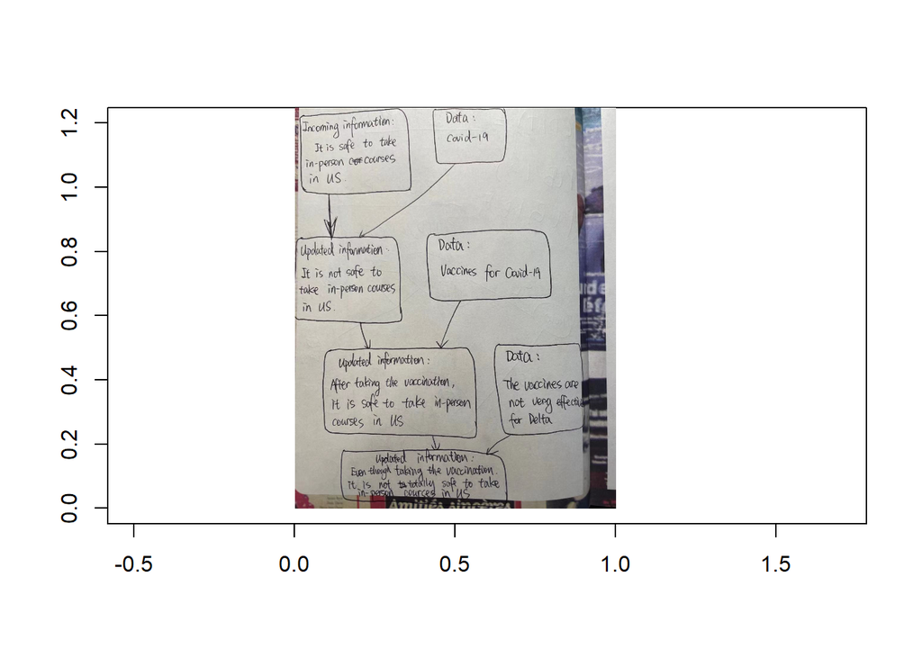

```r
library(png)
diagram <- readPNG("D:/diagram.png")
r <- nrow(diagram)/ncol(diagram)
plot(c(0,1.2), c(0,1.2), type = "n", xlab = "", ylab = "", asp = 1)
rasterImage(diagram, 0, 0, 1, r)
```

## Exercise 1.4

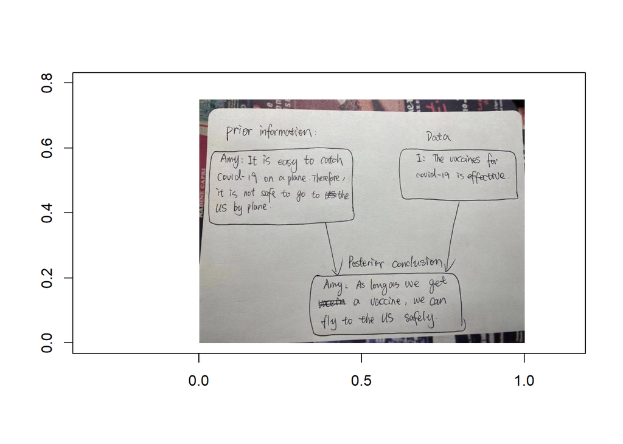

```r
diagram2 <- readPNG("D:/excersie4png.png")
r <- nrow(diagram2)/ncol(diagram2)
plot(c(0,0.8), c(0,0.8), type = "n", xlab = "", ylab = "", asp = 1)
rasterImage(diagram2, 0, 0, 1, r)
```

## Exercise 1.5

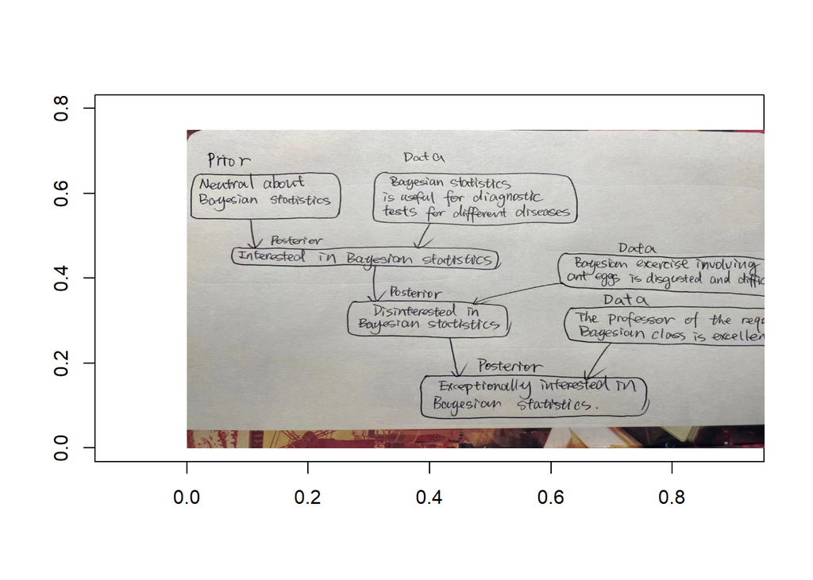

```r
diagram3 <- readPNG("D:/exercise5png.png")
r <- nrow(diagram3)/ncol(diagram3)
plot(c(0,0.8), c(0,0.8), type = "n", xlab = "", ylab = "", asp = 0.7)
rasterImage(diagram3, 0, 0, 1, r)
```

## Exercise 1.6

1. If I will not actually be offered a position, what is the chance that I would have been qualified for the position.
2. If I am qualified for a position, what is the chance that I will be offered the position.
3. I would rather have the answer to the Bayesian question because the application process is not repeated and the Bayesian question is more practical in our daily lives when I apply for a job.

## Exercise 1.7

1. Translation
2. Translators have great agency in translation.
3. Based on my current expertise, I think translators do have great agency in translation.
4. I will employ Bayesian framework here. The answer to question c is my prior information, the data is new translation I will read. Once I read a new translation, I will updated my prior information about this hopothesis.

## Excercise 1.8

1. Bayesian statistics can help people to ascertain a hypothesis based on the existing data, besides, with more data, the conclusion will be more clear.
2. Both Bayesian and and frequentist statistics aim to learn from data about the world around us. Moreover, with more data, the their conclusions are more likely to become the same. And with more data, the distinguishment between bayesain and frequentists statistics is less clear.